# Entrega1

2022-05-26

Todos los pacientes son de sexo femenino mayores de 21 años de herencia Pima. Para este primer estudio, lo que buscaremos es encontrar relaciones entre otras de las variables contenidas en el dataset.

## Punto 1

Se analizaron los datos y se llega a la conclusión de que todas las columnas se encuentran bien definidas.

La columna X parecería ser un contador ya que es siempre ascendiente aunque faltan algunos numeros, podría ser un identificador de muestras. Por lo tanto no lo tomamos en cuenta para los análisis siguientes.

Revisando los valores se nota que algunas filas tienen algunos valores en 0 que no tendrían mucho sentido en este contexto medicinal. Por ejemplo no se le encuentra mucho sentido que la presión sanguínea sea 0. Por lo tanto se comienza una exploración de datos para ver que porcentaje de los datos tienen valores en 0. Igualmente este análisis se deja para el punto 10 de selección de modelos.

## **Punto 2**

El modelo resulta

$\Omega$: Y= X$\beta$+$\epsilon$

Cuyos supuestos son:

1. Y $\sim$ $\mathcal{N}$(X$\beta$, $\sigma^2I$) , los valores de BMI

   Y $\in$ $\mathcal{R} ^{nx1}, n=539$ la cantidad de observaciones
2. $E(Y|X=x)= \beta_0+\beta_1x_1+...+\beta_{p-1}x_{p-1}$)
3. $Var(Y|X=x)$= $\sigma^2$
4. $Y_{1}, \ldots, Y_{n}$ son independientes

   Al definir los elementos
   $$Y=\left(y_{1}, \ldots, y_{n}\right)^{T}, \epsilon=\left(\epsilon_{1},
   \ldots, \epsilon_{n}\right)^{T}, \beta=\left(\beta_{1}, \ldots,
   \beta_{p}\right)^{T}$$

   $\beta\in$ $\mathcal{R} ^{px1}$

## Punto 3

La siguiente tabla muestra las correlaciones entre los distintos pares de variables del dataset. Se puede ver que en la última columna no se muestran los resultados como en las otras ya que la variable Outcome es una variable categórica.

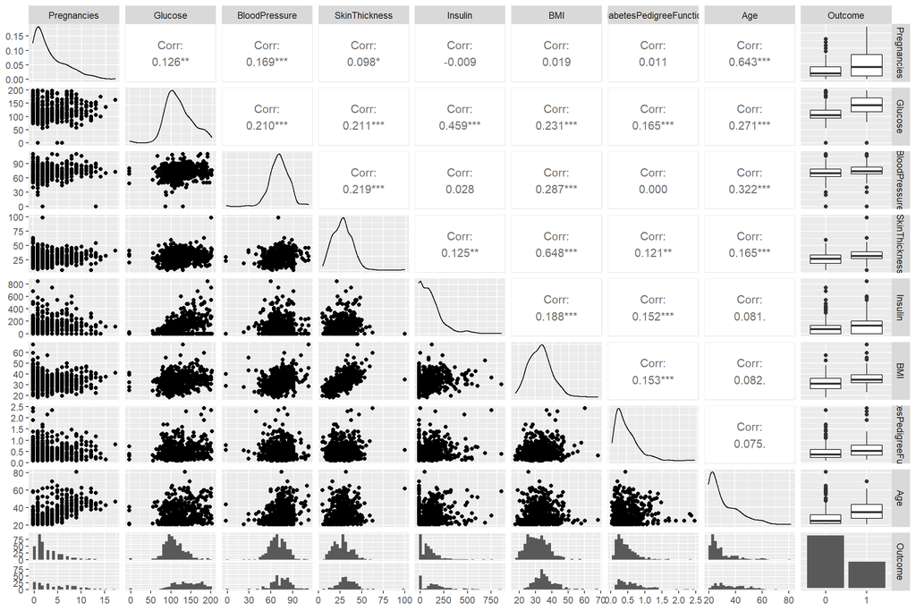

## Punto 4

Al ver la tabla podemos ver que existe una mayor correlación entre los valores de la SkinThickness y los de BMI, por lo que si tuviéramos que perder información eligiendo sólo una variable de las contenidas en el dataset sería la SkinThickness ya que sería un modelo de regresión lineal simple y la correlación da una noción de como explica una variable a la otra.

## Punto 5

```
##
## Call:
## lm(formula = data$BMI ~ vars, data = data)
##
## Residuals:
##      Min       1Q   Median       3Q      Max
## -23.4933  -3.3207  -0.6014   3.1331  22.2634
##
## Coefficients:
##                               Estimate Std. Error t value Pr(>|t|)
## (Intercept)                  13.977191   1.377092  10.150  < 2e-16 ***
## varsGlucose                  -0.002452   0.008304  -0.295   0.7679
## varsPregnancies              -0.083276   0.085507  -0.974   0.3305
## varsBloodPressure             0.092145   0.017893   5.150 3.68e-07 ***
## varsSkinThickness             0.378576   0.021711  17.437  < 2e-16 ***
## varsInsulin                   0.004816   0.001987   2.424   0.0157 *
## varsDiabetesPedigreeFunction  0.897675   0.650422   1.380   0.1681
## varsAge                      -0.063677   0.028000  -2.274   0.0234 *
## varsOutcome                   2.184222   0.546829   3.994 7.40e-05 ***
## ---
## Signif. codes:  0 '***' 0.001 '**' 0.01 '*' 0.05 '.' 0.1 ' ' 1
##
## Residual standard error: 4.98 on 530 degrees of freedom
## Multiple R-squared:  0.4825, Adjusted R-squared:  0.4747
## F-statistic: 61.78 on 8 and 530 DF,  p-value: < 2.2e-16
```

En la anterior tabla se puede ver el resultado de la regresión lineal múltiple.

En la parte de coeficientes cada fila expresa medidas de cada coeficiente de los parámetros estimados ($\beta_i$). La primer columna es el valor de la estimación, y después las otras tres columnas son tests de hipótesis para cada estimación de la siguiente forma:

$$H_{0}: \beta_{i}=0 \quad V s . \quad H_{1}: \beta_{i} \neq 0$$

La regla de decisión será

$$\varphi(\underline{X})= \begin{cases}1 & \text { si }
\quad|T|>k_{\alpha} \\ 0 & \text { en otro caso }\end{cases}$$

Donde

$$T=\frac{\hat{\beta_i}}{S \sqrt{d_{i i}}}, T ∼ t_{n - p}$$

Donde S es la estimación (insesgada) del desvío estándar del estimador.

Y $d_{ii}$ es el elemento de la matriz $D=\left(\mathbf{X}^{T} \mathbf{X}\right)^{-1}$

$k_{\alpha}$ es una constante que depende de $\alpha$ que es el nivel de significación del test.

Por último el p-valor se calcula de la siguiente manera:

$$p-\text { valor }=2 \mathbf{P}\left(T \geq\left|T_{o b s}\right|\right)$$

Entonces la columna de Std. Error es la multiplicación de $s$ y $\sqrt{d_{ii}}$, t value es el valor obtenido del estadístico T, osea: $\frac{\hat{\beta_i}}{s \sqrt{d_{i i}}}$

Y la última columna es el p valor obtenido para ese $t$, osea: $2 \mathbf{P}\left(T \geq\left|t\right|\right)$

Como ejemplo se toma la variable SkinThickness y se calcula a “mano” los valores:

$$S^{2}=\frac{\|Y-\hat{Y}\|^{2}}{n-p}$$

```r
Y_hat = predict(lin_reg)
s = sqrt(norm(as.matrix(data$BMI - Y_hat), type = "2")**2 / (539 - 8))
s
```

```
## [1] 4.975789
```

Que es el mismo que aparece en la tabla como Residual Standar Error.

```r
X = cbind(rep(c(1), 539), vars) # vars contiene las columnas en el orden igual al que se hizo la regresion lineal
D = solve(t(X) %*% X)
d44 = D[5, 5] # ya que el 0,0 sería el del intercept
std_err_b4 = (sqrt(d44) * s)
std_err_b4
```

```
## [1] 0.02169034
```

Que es el mismo valor que se obtiene en la tabla como Std. Error.

```r
t_b4 = unname(lin_reg$coefficients['varsSkinThickness']/std_err_b4)
t_b4
```

```
## [1] 17.45366
```

Que es el valor que se obtiene de la tabla como t value

Por último se puede calcular el p valor usando la función de distribución de la t de Student

```r
2*(1 - pt(t_b4, 539 - 8))
```

```
## [1] 0
```

## Punto 6

A medida que se agregan variables al modelo este valor siempre crece, a pesar de que estas nuevas variable no aporten a la estimación. Por eso es que cuando se quiere comparar dos modelos es preferible usar el coeficiente de determinación ajustado como:

$$R_{a}^{2}=1-\frac{n-1}{n-p}
\frac{\|Y-\hat{Y}\|^{2}}{\|Y-\bar{Y}\|^{2}}=1-\left(1-R^{2}\right)
\frac{n}{n-p}$$

## Punto 7

Si se quiere analizar si la regresión es significativa se puede hacer el siguiente test

$$H_{0}: \beta_{1}=\cdots=\beta_{p-1}=0
\quad \text { Vs. } \quad H_{1}: \text { Algun } \quad \beta_{i} \neq 0,
\quad i=1, \ldots, p-1$$

$$\varphi(\underline{X})= \begin{cases}1 & \text { si } \quad
F>\mathcal{F}_{p-1, n-p, 1-\alpha} \\ 0 & \text { en otro caso
}\end{cases}$$

Donde:

$$F=\frac{(C \hat{\beta})^{T}\left(C\left(\mathbf{X}^{T}
\mathbf{X}\right)^{-1} C^{T}\right)^{-1}(C \hat{\beta})}{(p - 1) S^{2}}$$

Con:

$$\mathbf{C}=\left[\begin{array}{ccc}0 & 1 \ldots & 0 \\0 & .
& . \\. & . & \cdot \\. & \cdot & \cdot \\0 &
\ldots & 1\end{array}\right] ; C\in \mathcal{R}^{(p-1)\times p}$$

Que representa la manera que está armado el test ($\beta_{1}=0 ; \beta_{2}=0 ...$)

En este caso el p-valor se calcula como:

$$p-\text { valor }=\mathbf{P}\left(F \geq F_{o b s}\right), \quad F \sim
\mathcal{F}_{p - 1, n-p}$$

Por lo tanto en este caso el p-valor está tan cercano a 0 que significa que la regresión es significativa.

## Punto 8

En el caso de querer obtener una estimación de la esperanza para el BMI, para una mujer que tuvo 2 embarazos, concentración de glucosa de 100, presión sanguínea de 70, piel de triceps de 20, sin diabetes, un valor de la función pedigree de 0.24 y 30 años usamos el modelo creado en el punto 5, cuyo valor resulta:

```r
predict(modelo, newdata)
```

```
##        1
## 28.61348
```

## Punto 9

Dado el modelo descrito en el punto 2, se quiere obtener un intervalo de confianza para la estimación de la esperanza de una nueva observación $\mathbf{E}\left(Y_{0}\right)=x_{0}^{T} \beta$
Para ello tenemos en cuenta el desarrollo del método del pivote utilizando
$$T=\frac{\hat{Y}_{0}-x_{0}^{T}
\beta}{S \sqrt{x_{0}^{T}\left(\mathbf{X}^{T} \mathbf{X}\right)^{-1}
x_{0}}} \sim t_{n-p}$$

que resulta en un intervalo de confianza

$$I C_{1-0.05}=\left[\hat{y_{0}}-t_{n-p,
1-\alpha / 2} S \sqrt{x_{0}^{T}\left(\mathbf{X}^{T}
\mathbf{X}\right)^{-1} x_{0}} ; \hat{y}_{0}+t_{n-p, 1-\alpha / 2} S
\sqrt{x_{0}^{T}\left(\mathbf{X}^{T} \mathbf{X}\right)^{-1} x_{0}}\right]$$

Puesto que el nivel que necesitamos es 0,95, el resultado es

```r
predict(modelo, newdata = newdata, interval = "confidence") #Intervalo de confianza de nivel 0.95 (por default)
```

```
##        fit      lwr      upr
## 1 28.61348 27.91714 29.30982
```

Además se desea un intervalo de predicción para la variable
$$\hat{Y}_{0}=x_{0}^{T} \hat{\beta}$$
,
$$\hat{Y}_{0} \sim \mathcal{N}\left(x_{0}^{T}
\beta, \sigma^{2} x_{0}^{T}\left(\mathbf{X}^{T} \mathbf{X}\right)^{-1}
x_{0}\right)$$

Nuevamente utilizando el método del pivote, resulta que el intervalo de predicción es:
$$I
C_{1-0.05}=\left[\hat{y}_{0}-t_{n-p, 1-\alpha / 2} S
\sqrt{1+x_{0}^{T}\left(\mathbf{X}^{T} \mathbf{X}\right)^{-1} x_{0}} ;
\hat{y}_{0}+t_{n-p, 1-\alpha / 2} S
\sqrt{1+x_{0}^{T}\left(\mathbf{X}^{T} \mathbf{X}\right)^{-1}
x_{0}}\right]$$

y el resultado:

```r
predict(modelo, newdata = newdata, interval = "prediction") #Intervalo de prediccion de nivel 0.95 (por default)
```

```
##        fit      lwr     upr
## 1 28.61348 18.62647 38.6005
```

Vemos que el intervalo de predicción es mayor que el de confianza, resultado esperado al tratar de obtener una predicción de un valor exacto.

## Punto 10

Para la selección de modelos se consideran todas las posibles combinaciones de variables para poder encontrar el mejor de los modelos. Para considerar cual es el mejor es necesario definir métricas.

Se utilizaran 3 métricas:

- $$R_{a}^{2}=1-\frac{n-1}{n-p} \frac{\|Y-\hat{Y}\|^{2}}{\|Y-\bar{Y}\|^{2}}$$
- $$C p=\frac{\left\|Y-\hat{Y}_{p}\right\|^{2}}{S^{2}}+2 p-n, \quad \quad
  S^{2}=\frac{\left\|Y-\hat{Y}_{k}\right\|^{2}}{n-k}$$
- $$\widehat{E C M}=\frac{1}{n} \sum_{i=1}^{n} r_{-i}^{2}=\frac{1}{n}
  \sum_{i=1}^{n} \frac{r^{2}}{\left(1-p_{i i}\right)^{2}}$$

La bondad de ajuste está dada por el $R_{a}^{2}$, mientras que la bondad de predicción está dada por el $C_p$ . Otra métrica también utilizada es el error cuadrático medio para verificar cuanto se aleja la estimación de la medición, para este caso se usó el método de CV para medir esta métrica.

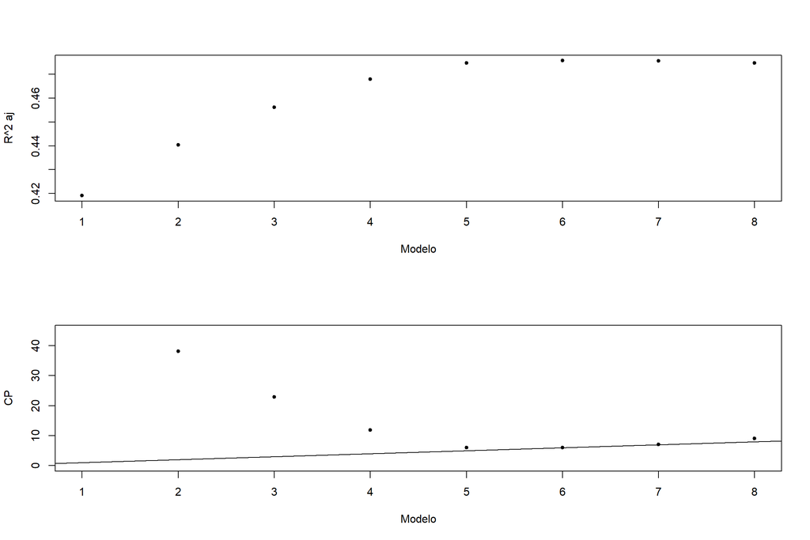

Utilizando la función regsubsets con el metodo exhaustivo se obtuvieron los mejores (se queda con el modelo con mayor F) modelos para la cantidad de variables. En el gráfico de arriba se pueden ver como cambia el $R_{a}^{2}$ y el $C_p$ a medida que cambian la cantidad de variables. De aquí se podría considerar que el óptimo se obtiene con 5 variables, pero no hay mucha diferencia con los menores. Teniendo en cuenta de que se prefiere usar menor cantidad de variables se podría tomar el de 4 o 3.

```
## Subset selection object
## Call: stepwise(data)
## 8 Variables  (and intercept)
##                              Forced in Forced out
## varsGlucose                      FALSE      FALSE
## varsPregnancies                  FALSE      FALSE
## varsBloodPressure                FALSE      FALSE
## varsSkinThickness                FALSE      FALSE
## varsInsulin                      FALSE      FALSE
## varsDiabetesPedigreeFunction     FALSE      FALSE
## varsAge                          FALSE      FALSE
## varsOutcome                      FALSE      FALSE
## 1 subsets of each size up to 8
## Selection Algorithm: exhaustive
##          varsGlucose varsPregnancies varsBloodPressure varsSkinThickness
## 1  ( 1 ) " "         " "             " "               "*"
## 2  ( 1 ) " "         " "             "*"               "*"
## 3  ( 1 ) " "         " "             "*"               "*"
## 4  ( 1 ) " "         " "             "*"               "*"
## 5  ( 1 ) " "         " "             "*"               "*"
## 6  ( 1 ) " "         " "             "*"               "*"
## 7  ( 1 ) " "         "*"             "*"               "*"
## 8  ( 1 ) "*"         "*"             "*"               "*"
##          varsInsulin varsDiabetesPedigreeFunction varsAge varsOutcome
## 1  ( 1 ) " "         " "                          " "     " "
## 2  ( 1 ) " "         " "                          " "     " "
## 3  ( 1 ) " "         " "                          " "     "*"
## 4  ( 1 ) " "         " "                          "*"     "*"
## 5  ( 1 ) "*"         " "                          "*"     "*"
## 6  ( 1 ) "*"         "*"                          "*"     "*"
## 7  ( 1 ) "*"         "*"                          "*"     "*"
## 8  ( 1 ) "*"         "*"                          "*"     "*"
```

En esta tabla se puede ver cuales variables se utilizan para la cantidad de variables.

Para calcular el error cuadratico medio en cambio se usa la función bestglm ya que elije el mejor modelo (en este caso se le puede pedir que el mejor sea el que tenga menor ECM) usando cross validation.

```
##    (Intercept) Glucose Pregnancies BloodPressure SkinThickness Insulin
## 0         TRUE   FALSE       FALSE         FALSE         FALSE   FALSE
## 1         TRUE   FALSE       FALSE         FALSE          TRUE   FALSE
## 2         TRUE   FALSE       FALSE          TRUE          TRUE   FALSE
## 3         TRUE   FALSE       FALSE          TRUE          TRUE   FALSE
## 4*        TRUE   FALSE       FALSE          TRUE          TRUE   FALSE
## 5         TRUE   FALSE       FALSE          TRUE          TRUE    TRUE
## 6         TRUE   FALSE       FALSE          TRUE          TRUE    TRUE
## 7         TRUE   FALSE        TRUE          TRUE          TRUE    TRUE
## 8         TRUE    TRUE        TRUE          TRUE          TRUE    TRUE
##    DiabetesPedigreeFunction   Age Outcome logLikelihood       CV
## 0                     FALSE FALSE   FALSE    -1038.3862 47.65700
## 1                     FALSE FALSE   FALSE     -891.4980 28.48801
## 2                     FALSE FALSE   FALSE     -880.9594 28.05999
## 3                     FALSE FALSE    TRUE     -872.7179 27.48996
## 4*                    FALSE  TRUE    TRUE     -866.2922 27.26823
## 5                     FALSE  TRUE    TRUE     -862.3907 27.28109
## 6                      TRUE  TRUE    TRUE     -861.3503 27.62445
## 7                      TRUE  TRUE    TRUE     -860.8852 27.99989
## 8                      TRUE  TRUE    TRUE     -860.8408 28.43241
```

Este algoritmo encuentra que el mejor modelo (el que minimiza el ECM) es el de 4 variables.

## Punto 11

Recordando los supuestos del modelo:

1. . Los errores tienen media cero E($\epsilon$)=0
2. Homocedasticidad: los errores tienen todos la misma varianza  
   Var($\epsilon$)= $\sigma^2$
3. Los errores tienen distribución normal, son independientes entre sí y no están correlacionados con las variables de entrada

Que también se pueden ver como

1. Y $\sim$ $\mathcal{N}$(X$\beta$, $\sigma^2I$)
2. $E(Y|X=x)= \beta_0+\beta_1x_1+...+\beta_{p-1}x_{p-1}$
3. $Var(Y|X=x)$= $\sigma^2$
4. $Y_{1}, \ldots, Y_{n}$ son independientes

Al tener un modelo multivariable es necesario analizar los residuos para comprender si los supuestos son válidos en el modelo propuesto. En principio, el mirar un gráfico de los residuos y reconocer patrones es un indicio de que el modelo no es adecuado. Deberían ser puntos distribuidos aleatoriamente con media cero.

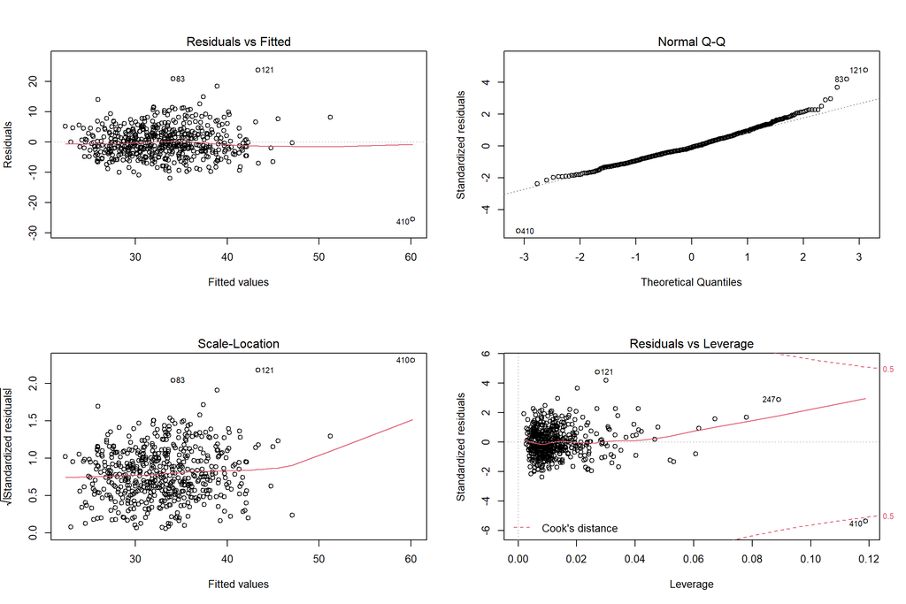

```r
par(mfrow = c(2, 2))
plot(modelo)
```

```r
#
# residuals_std<-rstandard(modelo) #t-residuals
#
# ggplot(data=data, aes(x=1:length(modelo$residuals), y=modelo$residuals)) +
#   geom_point(col="gray0", fill="darkorchid3", alpha = .9) +
#   labs(title="Residuos", x="Indice", y="Valores") + xlim(c(0,length(modelo$residuals))) + ylim(c(min(modelo$residuals),max(modelo$residuals)))
```

En el gráfico superior izquierdo se puede verificar que la media es nula, y el supuesto de linealidad es válido.

Además, sabemos que podemos comprar ,mediante el gráfico superior derecho, la normalidad de los supuestos. Vemos que los residuos siguen una distribución normal.

Luego, con el gráfico inferior izquierdo podemos comprobar la homeocedasticidad, puesto que la varianza de los residuos es relativamente constante.

Con el gráfico inferior derecho se verifica la presencia de outliers, que son valores extremos dentro de nuestro set y que pueden afectar al Residual Standar Error.

## Punto 12

Como se había elegido la columna SkinThickness, se realiza el bootstrap no paramétrico y como remuestra se toma la salida de la regresión simple. Se toman 10000 muestras del estimador y se gráfica la densidad usando nucleo gaussiano, se compara contra una normal y se calculan la media y el desvío estandard.

```r
mean(estimations)
```

```
## [1] 0.4271824
```

```r
var(estimations)
```

```
## [1] 0.001413549
```

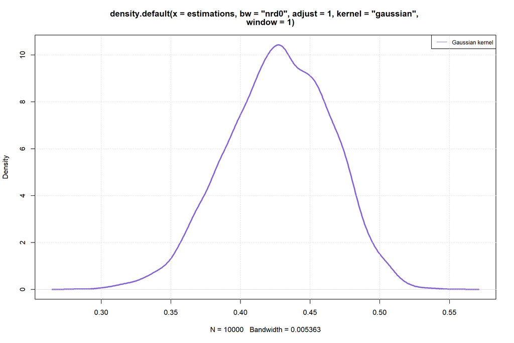

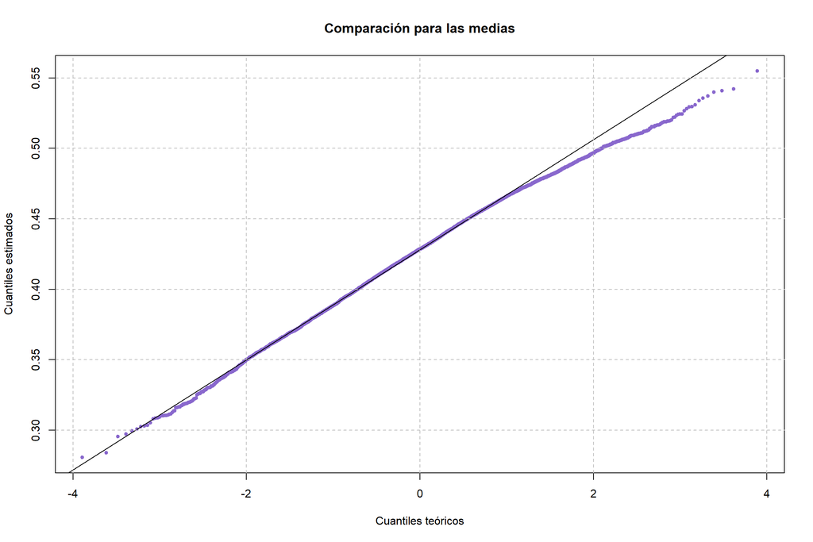

Se puede notar que es similar a una gaussiana, esto es útil ya que indica que el valor no varía mucho.